# Homework 7

Tyler Schappe

## 3.4

### e)

#### Implement this model in c) using JAGS and compare the results with the results in c).

Use the full conditional distributions derived in the hand-written notes

Load the data

```r
library(invgamma); library(reshape2); library(ggplot2); library(tidybayes); library(rjags); library(ggstance); library(HDInterval)
Y <- 1:10; a=10; N=10
data.3.4 <- list(Y=Y, a=a, N=N)
```

Define the model

```r
jags.mod.3.4.string <- textConnection("
  model{
    #Likelihood
    for (i in 1:N) {
      Y[i] ~ dnorm(0, tau[i])
      tau[i] ~ dgamma(a, b)
    }

    #Priors
    b ~ dgamma(1,1)
    sigma <- 1/sqrt(tau)

  }
  ")
```

Define initial values and compile model

```r
inits <- list(b=1)
jags.mod.3.4 <- jags.model(jags.mod.3.4.string, data=data.3.4, inits=inits, n.chains=4)
```

10000-sample burn-in

```r
update(jags.mod.3.4, 10000)
```

Generate 20,000 post-burn-in samples

```r
params <- c("tau", "sigma", "b")
jags.samples.3.4 <- coda.samples(jags.mod.3.4, variable.names = params, n.iter = 20000, progress.bar="none")
```

Look at summary of output

```r
summary(jags.samples.3.4)
```

```
##
## Iterations = 10001:30000
## Thinning interval = 1
## Number of chains = 4
## Sample size per chain = 20000
##
## 1. Empirical mean and standard deviation for each variable,
##    plus standard error of the mean:
##
##              Mean      SD  Naive SE Time-series SE
## b         30.2369 4.33379 0.0153223      0.0271202
## sigma[1]   1.7699 0.31458 0.0011122      0.0014159
## sigma[2]   1.8119 0.32053 0.0011332      0.0014434
## sigma[3]   1.8833 0.32918 0.0011638      0.0014369
## sigma[4]   1.9780 0.34085 0.0012051      0.0014127
## sigma[5]   2.0928 0.35989 0.0012724      0.0014878
## sigma[6]   2.2212 0.37671 0.0013319      0.0014997
## sigma[7]   2.3672 0.39856 0.0014091      0.0015511
## sigma[8]   2.5221 0.42050 0.0014867      0.0015754
## sigma[9]   2.6908 0.44875 0.0015866      0.0016592
## sigma[10]  2.8665 0.47704 0.0016866      0.0017955
## tau[1]     0.3487 0.11939 0.0004221      0.0005470
## tau[2]     0.3324 0.11295 0.0003993      0.0005145
## tau[3]     0.3070 0.10278 0.0003634      0.0004585
## tau[4]     0.2777 0.09160 0.0003239      0.0003866
## tau[5]     0.2479 0.08139 0.0002878      0.0003418
## tau[6]     0.2195 0.07080 0.0002503      0.0002828
## tau[7]     0.1931 0.06177 0.0002184      0.0002429
## tau[8]     0.1698 0.05369 0.0001898      0.0002038
## tau[9]     0.1492 0.04712 0.0001666      0.0001771
## tau[10]    0.1314 0.04124 0.0001458      0.0001546
##
## 2. Quantiles for each variable:
##
##               2.5%     25%     50%     75%   97.5%
## b         22.44141 27.1918 29.9936 32.9950 39.4318
## sigma[1]   1.26595  1.5481  1.7322  1.9482  2.4946
## sigma[2]   1.29720  1.5862  1.7729  1.9923  2.5555
## sigma[3]   1.35799  1.6508  1.8438  2.0706  2.6344
## sigma[4]   1.43393  1.7377  1.9365  2.1712  2.7645
## sigma[5]   1.51823  1.8386  2.0492  2.2968  2.9173
## sigma[6]   1.62322  1.9541  2.1737  2.4358  3.0942
## sigma[7]   1.73727  2.0833  2.3200  2.5946  3.2834
## sigma[8]   1.85681  2.2244  2.4693  2.7616  3.4892
## sigma[9]   1.98119  2.3727  2.6337  2.9450  3.7239
## sigma[10]  2.11348  2.5271  2.8072  3.1331  3.9647
## tau[1]     0.16069  0.2635  0.3333  0.4173  0.6240
## tau[2]     0.15312  0.2519  0.3181  0.3975  0.5943
## tau[3]     0.14410  0.2333  0.2942  0.3670  0.5423
## tau[4]     0.13085  0.2121  0.2667  0.3312  0.4863
## tau[5]     0.11750  0.1896  0.2381  0.2958  0.4338
## tau[6]     0.10445  0.1685  0.2116  0.2619  0.3795
## tau[7]     0.09276  0.1485  0.1858  0.2304  0.3313
## tau[8]     0.08214  0.1311  0.1640  0.2021  0.2900
## tau[9]     0.07211  0.1153  0.1442  0.1776  0.2548
## tau[10]    0.06362  0.1019  0.1269  0.1566  0.2239
```

#### Run the hand-coded Gibbs sampler to compare to

Define the Gibbs sampler parameters, initial values, and priors

```r
S <- 30000
samples <- matrix(NA, S, 11)
#Inits
sigma.sq <- rep(var(Y), 10)
b=1; a=10
```

Make the Gibbs sampler

```r
for (s in 1:S) {
  for (n in 1:N) {
    sigma.sq[n] <- rinvgamma(1, shape=a+1/2, rate = 0.5*Y[n]^2 + b)
  }
  b <- rgamma(1, shape=(N*a + 1), rate = (sum(1/sigma.sq) + 1))
  samples[s,] <- c(sigma.sq, b)
}
```

Gather the draws

```r
colnames(samples) <- c("sigma.sq1", "sigma.sq2", "sigma.sq3", "sigma.sq4", "sigma.sq5", "sigma.sq6", "sigma.sq7", "sigma.sq8", "sigma.sq9", "sigma.sq10", "b")
samples.melt <- as.data.frame(melt(samples))
colnames(samples.melt) <- c("iter", "parameter", "value")
samples.melt <- samples.melt[samples.melt$iter > 5000, ]
samples.melt$parameter <- as.factor(samples.melt$parameter)
```

Compare the 95% quantiles and the medians of each method

```r
#Grab the summary of the samples for the quantiles
jags.samples.3.4.sum <- summary(jags.samples.3.4)
#Organize them and square the sigma samples to be able to compare to the sigma squared values from the custom Gibbs sampler
compare.jags.custom <- as.data.frame(rbind(jags.samples.3.4.sum$quantiles[1, c(1,3,5)], (jags.samples.3.4.sum$quantiles[2:11,c(1,3,5)])^2))
#Grab the quantiles from the custom Gibbs sampler
compare.jags.custom$custom.gibbs.2.5 <- c( quantile(samples[,11], 0.025), apply(samples[,1:10], 2, FUN = function(x) quantile(x, 0.025)))
compare.jags.custom$custom.gibbs.50 <- c( quantile(samples[,11], 0.5), apply(samples[,1:10], 2, FUN = function(x) quantile(x, 0.5)))
compare.jags.custom$custom.gibbs.97.5 <- c( quantile(samples[,11], 0.975), apply(samples[,1:10], 2, FUN = function(x) quantile(x, 0.975)))
#Make a parameter name column
compare.jags.custom$par  <- c("b", "sigma.sq1", "sigma.sq2", "sigma.sq3", "sigma.sq4", "sigma.sq5", "sigma.sq6", "sigma.sq7", "sigma.sq8", "sigma.sq9", "sigma.sq10")
#Stack them on top of each other by method
compare.jags.custom2 <- as.data.frame(rbind(as.matrix(compare.jags.custom[,c(1:3,7)]), as.matrix(compare.jags.custom[,c(4:7)])))
colnames(compare.jags.custom2)[1:3] <- c("lower.CI", "median", "upper.CI")
#Add a method column
compare.jags.custom2$method <-  c(rep("jags", 11), rep("custom", 11))
#Get into proper data type
compare.jags.custom2[,1] <- as.numeric(as.character(compare.jags.custom2[,1])); compare.jags.custom2[,2] <- as.numeric(as.character(compare.jags.custom2[,2])); compare.jags.custom2[,3] <- as.numeric(as.character(compare.jags.custom2[,3]))
compare.jags.custom2$method <- as.factor(compare.jags.custom2$method)
compare.jags.custom2
```

|  | lower.CI | median | upper.CI | par | method |
| --- | --- | --- | --- | --- | --- |
| X | 22.441407 | 29.993604 | 39.431761 | b | jags |
| sigma.1. | 1.602622 | 3.000436 | 6.223063 | sigma.sq1 | jags |
| sigma.2. | 1.682718 | 3.143269 | 6.530796 | sigma.sq2 | jags |
| sigma.3. | 1.844131 | 3.399553 | 6.939803 | sigma.sq3 | jags |
| sigma.4. | 2.056162 | 3.750218 | 7.642339 | sigma.sq4 | jags |
| sigma.5. | 2.305033 | 4.199218 | 8.510742 | sigma.sq5 | jags |
| sigma.6. | 2.634832 | 4.724875 | 9.574375 | sigma.sq6 | jags |
| sigma.7. | 3.018106 | 5.382385 | 10.780615 | sigma.sq7 | jags |
| sigma.8. | 3.447732 | 6.097330 | 12.174355 | sigma.sq8 | jags |
| sigma.9. | 3.925126 | 6.936359 | 13.867283 | sigma.sq9 | jags |

[output cut: 12 more lines]

Make a summary plot of the quantiles of each method to compare

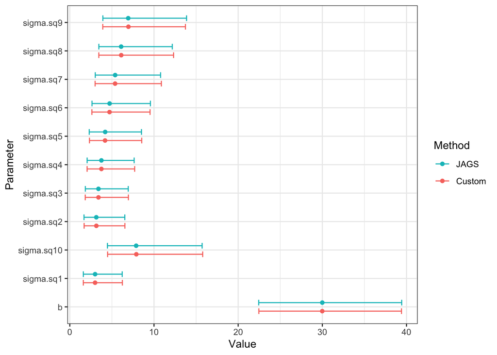

```r
nudge <- position_dodgev(height=0.6)
ggplot(aes(x=median, y=par, color=method), data=compare.jags.custom2)+
  theme_bw()+
  geom_point(position=nudge)+
  geom_errorbarh(aes(y=par, xmin=lower.CI, xmax=upper.CI, color=method), height=0.4, position=nudge)+
  scale_color_discrete(name="Method", breaks = c("jags", "custom"), labels = c("JAGS", "Custom"))+
  xlab("Value")+
  ylab("Parameter")
```

The two methods perform very similarly, but it looks like JAGS tends to have slighly lower values for the medians and the upper quantiles.

## 3.6

### a)

#### Explain why this is a resonable prior for theta_i.

It’s a resonable prior because of how we interpret the parameters of a beta distribution prior, which is that alpha is the number of prior successes and beta is the number of prior failures. We have prior information in the form of the overall freethrow percentages of each player, but we need to turn that into a number of successes and failures. We don’t know and can’t really guess those values since they depend on the number of attempts of each player. To solve this, we make a simplification that each player had the same number of prior attempts and model it as exp(m) where m is normal random variable; because of the exponent, each players overall freethrow proportion gets multiplied by some number to convert it to prior successes and failures, and we estimate the value of m from the data.

### b)

#### Explain the role of m in the prior.

The role of m is to allow the overall free-throw percentage of each player to be turned into a prior number of successes and failures, which is how we interpret the alpha and beta parameters of the beta distribution. Since we don’t know and can’t guess the overall number of freethrow attempts for each player, an easy way is to assume that they all had the same number of attempts, exp(m), and estimate the value of m from the data. It has to be a positive number, so we exponentiate a normal random variable and give it a very uninformative prior.

### c)

See hand-written notes

### d)

#### Write you own MCMC algorithm to compute a table of posterior means and 95% credible intervals for all 11 model parameters.

Since the theta-is have conjugate beta priors, but m has a non-conjugate Normal prior, it would be best to use the Gibbs-within-Metropolis sampling method.

Load the data

```r
players <- data.frame(rbind(
            c(0.845, 64, 75, "Russell Westbrook"),
            c(0.847, 72, 95, "James Harden"),
            c(0.880, 55, 63, "Kawhi Leonard"),
            c(0.674, 27, 39, "LeBron James"),
            c(0.909, 75, 83, "Isaiah Thomas"),
            c(0.898, 24, 26, "Stephen Curry"),
            c(0.770, 28, 41, "Giannis Antetokounmpo"),
            c(0.801, 66, 82, "John Wall"),
            c(0.802, 40, 54, "Anthony Davis"),
            c(0.875, 13, 16, "Kevin Durant")
  )
)
colnames(players) <- c("overall", "clutch", "attempts", "player")
players$overall <- as.numeric(as.character(players$overall))
players$clutch <- as.integer(as.character(players$clutch))
players$attempts <- as.integer(as.character(players$attempts))
N <- nrow(players)
```

Define the sampler parameters and initial values

```r
S <- 200000
samples <- matrix(NA, S, 11)
prop <- rep(0, S)
#Inits
#Use 0.1 as initial value for all thetas -- want to make sure that we don't bias the chains at all.
theta <- rep(0.1, 10)
#0 corresponds to a single prior observation for the beta prior
m = 0
can_sd <- 1.2
```

Note: the standard deviation for the candidate distribution was tuned during several burn-in runs of 20000 so that the acceptance probability is about 0.4. Thus, this represents a ‘final’ run with that tuning parameter set to a fixed value.

Make a log posterior function for the sampler

```r
log_post_m <- function(theta, m, q) {
  #Likelihood is the sum of the i beta priors with log parameterization
  lik <- sum(dbeta(theta, shape1=(exp(m)*q), shape2=(exp(m)*(1-q)), log = TRUE))
  #Prior for m is N(0, 10)
  prior <- dnorm(m, mean=0, sd=sqrt(10), log=TRUE)
  #Posterior is log(lik) + log(prior)
  post <- lik + prior
  return(post)
}
```

Make the Metropolis-Gibbs sampler

```r
for (s in 1:S) {

  ############################
  ###Metropolis sampling for m
  ############################
  #Candidate value for m randomly drawn from N(previous m, candidate_sd)
  can <- rnorm(1, mean=m, sd=can_sd)
  #Calculate the acceptance ratio as the difference in the log posterior of the candidate m minus the current m
  logR <- log_post_m(theta, can, players$overall) - log_post_m(theta, m, players$overall)
  #If statement to accept with prob min(1, R)
  if (log(runif(1)) < logR) {
    #If accepted, assign candidate as new value for m
    m <- can
  }
  #Ifelse statement that saves a value of 1 if the candidate is accepted and 0 if not
  #This is used for tuning the can_sd parameter
  prop.out <- ifelse(log(runif(1)) < logR, 1, 0)

  ##########################
  #Gibbs sampling for thetas
  ##########################
  #Loop through each of the 10 theta parameters and sample from the full conditional posterior derived in the hand-written notes
  for (i in 1:N) {
    theta[i] <- rbeta(1, shape1=(players[i, 2] + exp(m)*players[i, 1]), shape2 = (players[i, 3] - players[i, 2] + exp(m)*(1 - players[i, 1])))
  }

  #Save the samples
  samples[s,] <- c(theta, m)
  #Save the acceptance indicator
  prop[s] <- prop.out
}

#Calculate the acceptance proportion
mean(prop)
```

```
## [1] 0.427475
```

Gather the draws

```r
#Get the posterior draws into a neater format for plotting
colnames(samples) <- c("theta1", "theta2", "theta3", "theta4", "theta5", "theta6", "theta7", "theta8", "theta9", "theta10", "m")
samples.melt <- as.data.frame(melt(samples))
colnames(samples.melt) <- c("iter", "parameter", "value")
#Discard the first 100,000 samples as burn-in
samples.melt <- samples.melt[samples.melt$iter > 100000, ]
samples.melt$parameter <- as.factor(samples.melt$parameter)
```

Make convergence plots

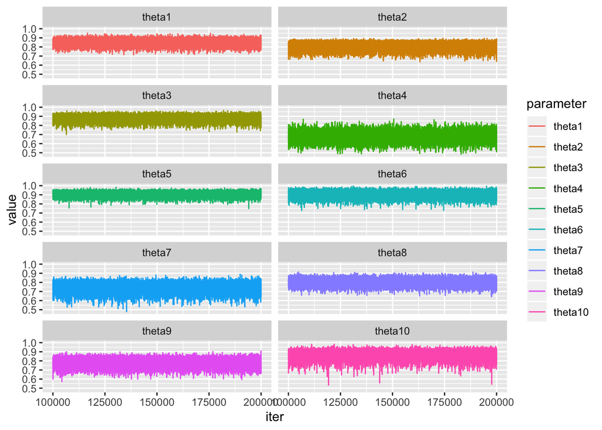

```r
(convergence.plot1 <- qplot(iter, value, color=parameter, geom="line", data=samples.melt[samples.melt$parameter != "m" ,])+facet_wrap(~parameter, ncol=2))
```

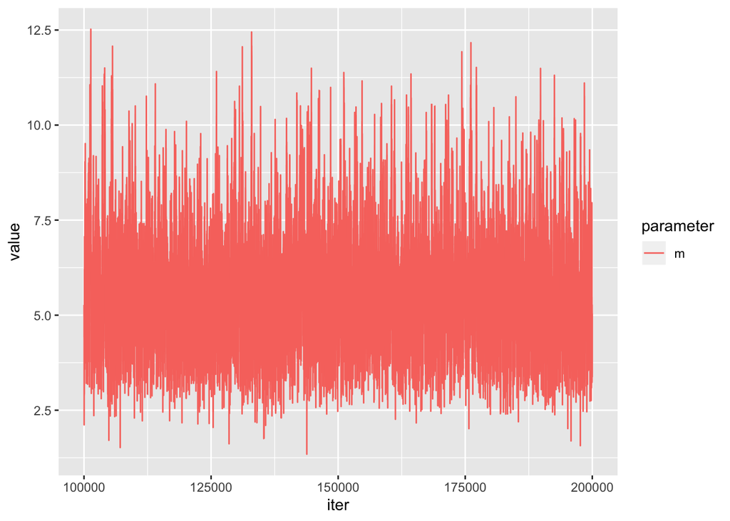

```r
(convergence.plot2 <- qplot(iter, value, color=parameter, geom="line", data=samples.melt[samples.melt$parameter == "m" ,]))
```

Make a table with posterior means and 95% credible intervals

```r
(hand.alg.table <- t(rbind(apply(samples, 2, FUN = function(x) mean(x)), apply(samples, 2, FUN = function(x) hdi(x, credMass = 0.95)))))
```

```
##                       lower     upper
## theta1  0.8473782 0.8018820 0.8939189
## theta2  0.8180527 0.7533897 0.8632595
## theta3  0.8781140 0.8343766 0.9214313
## theta4  0.6774737 0.6110365 0.7485886
## theta5  0.9073516 0.8698893 0.9424590
## theta6  0.9015206 0.8565622 0.9484421
## theta7  0.7529710 0.6787714 0.8111426
## theta8  0.8021649 0.7525126 0.8528969
## theta9  0.7876397 0.7233645 0.8410082
## theta10 0.8689529 0.8109827 0.9228503
## m       5.6022907 3.0659887 8.5300223
```

### e)

#### Fit the same model in JAGS and comment on whether the two algorithms returned the same results

Define the data

```r
data.3.6 <- list(N=nrow(players), Y=as.integer(players$clutch), n=as.integer(players$attempts), q=players$overall)
```

Define the model

```r
jags.mod.3.6.string <- textConnection("
  model{
    #Likelihood
    for (i in 1:N) {
      Y[i] ~ dbinom(theta[i], n[i])
      theta[i] ~ dbeta(exp(m)*q[i], exp(m)*(1-q[i]))
    }

    #Priors
    m ~ dnorm(0, 10)
  }
  ")
```

Define initial values and compile model

```r
inits <- list(m=1, theta=rep(0.1, 10))
jags.mod.3.6 <- jags.model(jags.mod.3.6.string, data=data.3.6, inits=inits, n.chains=4)
```

20000-sample burn-in

```r
update(jags.mod.3.6, 20000)
```

Generate 30,000 post-burn-in samples

```r
params <- c("theta", "m")
jags.samples.3.6 <- coda.samples(jags.mod.3.6, variable.names = params, n.iter = 30000)
```

Look at traceplots

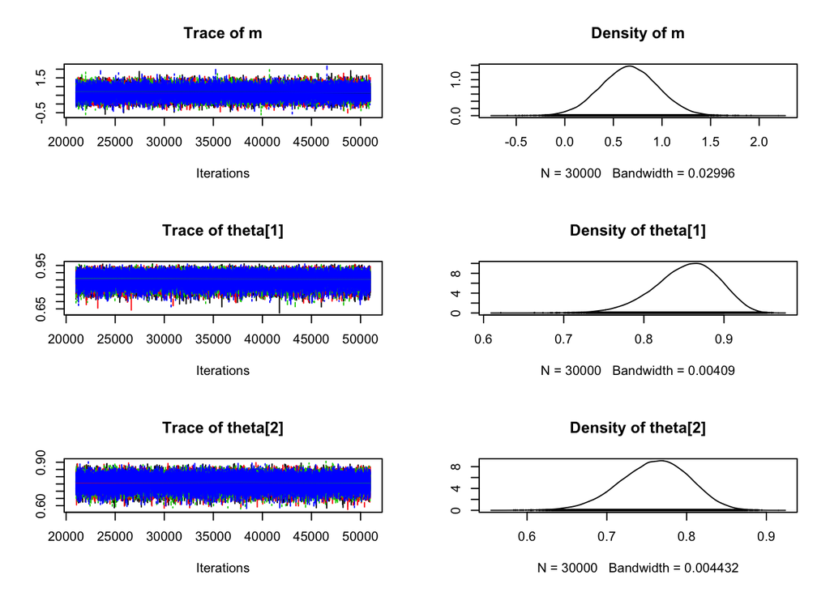

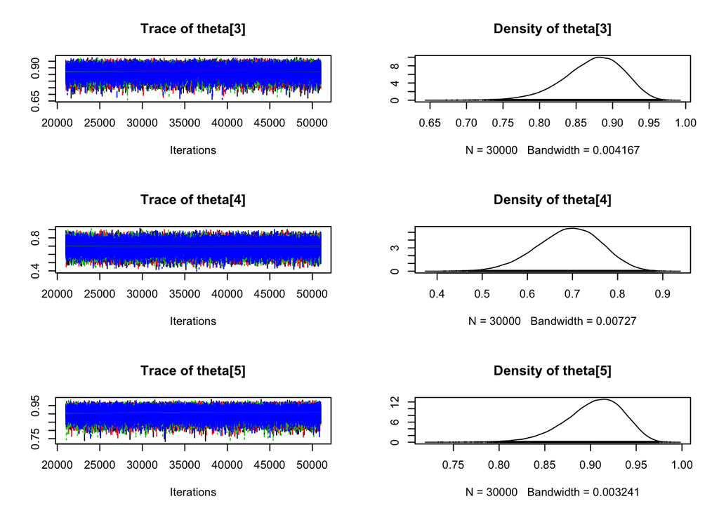

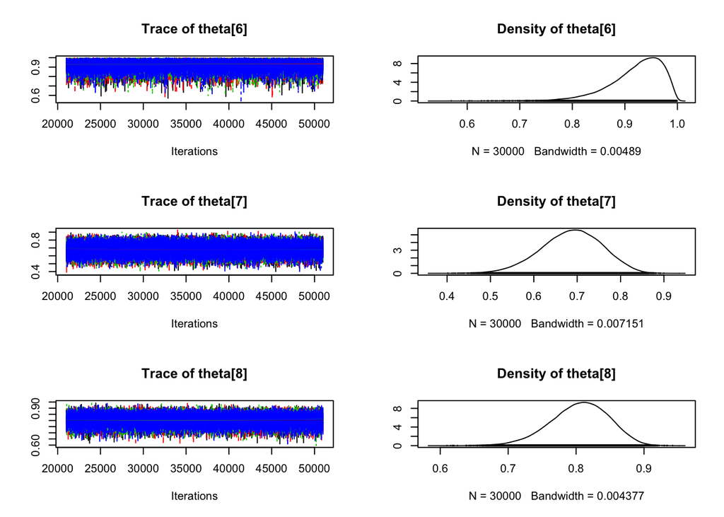

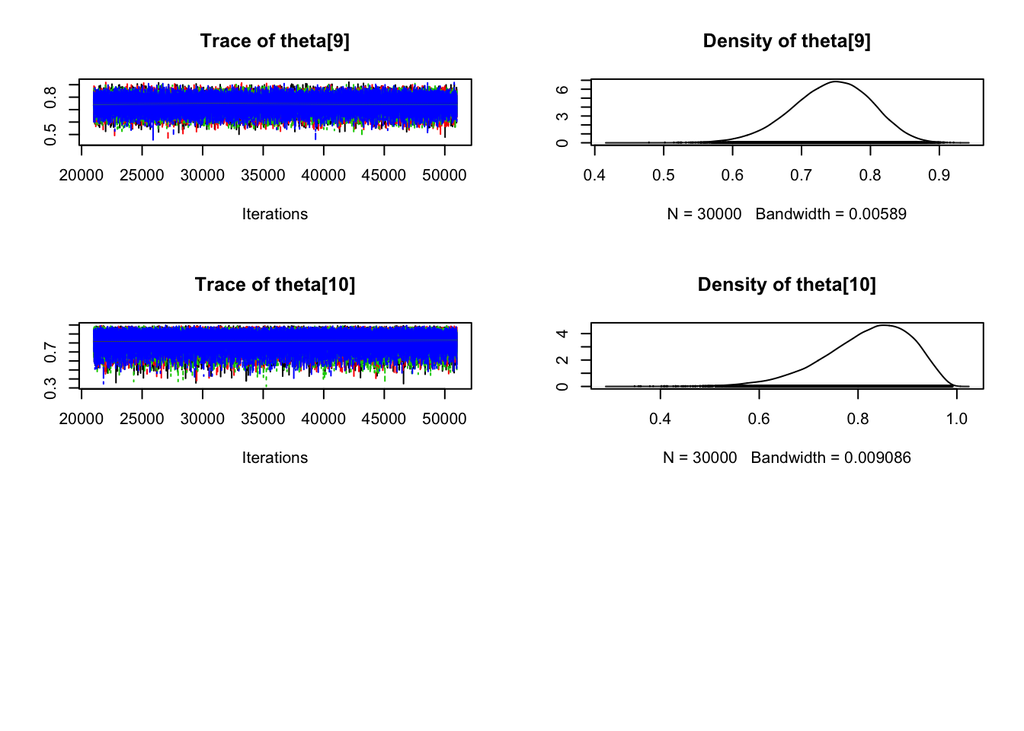

```r
plot(jags.samples.3.6)
```

Look at posterior means and 95% HDIs

```r
jags.3.6.sum <- summary(jags.samples.3.6)
jags.3.6.table <- (cbind(c(jags.3.6.sum$statistics[2:11,1], jags.3.6.sum$statistics[1,1]), c(jags.3.6.sum$quantiles[2:11,1], jags.3.6.sum$quantiles[1,1]), c(jags.3.6.sum$quantiles[2:11,5], jags.3.6.sum$quantiles[1,5])))
colnames(jags.3.6.table) <- c("mean", "2.5%", "97.5%")
jags.3.6.table
```

```
##                mean       2.5%     97.5%
## theta[1]  0.8533283 0.76684164 0.9222817
## theta[2]  0.7597077 0.67012242 0.8390350
## theta[3]  0.8732425 0.78231966 0.9419003
## theta[4]  0.6913280 0.54379944 0.8210824
## theta[5]  0.9036546 0.83257007 0.9564208
## theta[6]  0.9213157 0.79843554 0.9885317
## theta[7]  0.6866714 0.54183031 0.8149014
## theta[8]  0.8049756 0.71416473 0.8814087
## theta[9]  0.7432269 0.62244167 0.8474971
## theta[10] 0.8185935 0.61468170 0.9553714
##           0.6627641 0.08539365 1.2354105
```

Make a figure of the means and 95% CIs to see whether the results were similar for the hand-coded algorithm vs JAGS

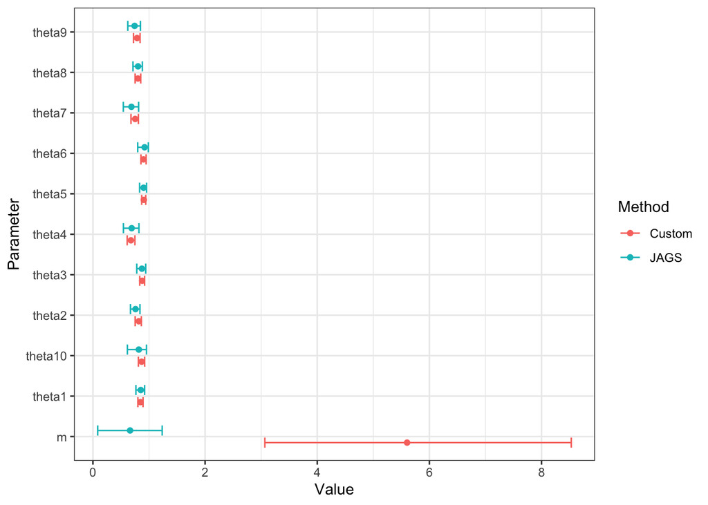

```r
compare.df <- as.data.frame(rbind(hand.alg.table, jags.3.6.table))
colnames(compare.df) <- c("mean", "lower.CI", "upper.CI")
compare.df$method <- c(rep("hand-coded", 11), rep("JAGS", 11))
compare.df$parameter <- rep(rownames(compare.df)[1:11], 2)

ggplot(aes(y=parameter, x=mean, color=method), data=compare.df)+
  theme_bw()+
  geom_point(position=nudge)+
  geom_errorbarh(aes(xmin=compare.df$lower, xmax=compare.df$upper, y=compare.df$parameter, color=method), height=0.5, position=nudge)+
  # geom_errorbarh(aes(y=par, xmin=lower.CI, xmax=upper.CI, color=method), height=0.4, position=nudge)+
  scale_color_discrete(name="Method", breaks = c("hand-coded", "JAGS"), labels = c("Custom", "JAGS"))+
  xlab("Value")+
  ylab("Parameter")
```

Given that the chains seem to be mixing well for both methods here, it seems odd that they give such different values. At first I thought it was a coding error on my part, but I couldn’t find anything wrong with the custom algorithm. I’m still not sure why they give such different answers.

### f)

The advantages of the JAGS method is that there is much less work up front specifying the model because you don’t need to derive full conditional distributions or come up with a function to compute the log posterior. Other advantages include the fact that you don’t need to code the sampling algorithm, you can run multiple chains simultaneously, there is seemingly automatic adjustment of tuning parameters, and there are built-in functions to summarize the draws and quickly make trace plots. The biggest disadvantage is that you don’t really know what’s going on ‘under the hood’ in the sampling from the posterior, so you have less understanding of the functions and distributions underlying the sampling.

The main advantage of the custom algorithm is that by making it, you learn a lot about the math behind the scenes since you have to think about whether you priors are conjugate or not, and whether to use Gibbs or Metropolis sampling or both. You also have a lot more control over the fine details, like the candidate distribution and the tuning parameters. The disadvantages include the time and effort to code it, the fact that it can only run one chain at a time (but this can easily be changed), and the slow speed that it runs at.

## 3.7

#### Model the observations Y1 . . Y82 using the Student-t distribution with location mu, scale sigma and degrees of freedom k. Assume prior distributions mu ~ N(0, 10000^2), 1/sigma^2 = tau ~ Gamma(0.01, 0.01), and k ~ Unif(1,30).

```r
library(MASS)
data(galaxies)
# ?galaxies
Y <- galaxies
n <- length(Y)
# hist(Y, breaks=25)
```

### a)

#### Give reasonable initial values for each of the three parameters

For initial values for mu and tau, use the corresponding values from the sample. For the degrees of freedom parameter, use 1 because from the data it looks like the tails will need to be pretty fat.

```r
mu.init <- mean(Y)
tau.init <- 1/var(Y)
k.init <- 1
```

### b)

#### Fit the model using JAGS. Report trace plots of each parameter and discuss convergence

Define the data

```r
data.3.7 <- list(n=n, Y=Y)
```

Define the model

```r
jags.mod.3.7.string <- textConnection("
  model{
    #Likelihood
    for (i in 1:n) {
      Y[i] ~ dt(mu, tau, k)
    }

    #Priors
    mu ~ dnorm(0, 1/(10000^2))
    tau ~ dgamma(0.01, 0.01)
    k ~ dunif(1, 30)
  }
  ")
```

Define initial values and compile model

```r
inits <- list(mu = mu.init, tau=tau.init, k = k.init)
jags.mod.3.7 <- jags.model(jags.mod.3.7.string, data=data.3.7, inits=inits, n.chains=4)
```

20000-sample burn-in

```r
update(jags.mod.3.7, 20000)
```

Generate 30,000 post-burn-in samples

```r
params <- c("mu", "tau", "k")
jags.samples.3.7 <- coda.samples(jags.mod.3.7, variable.names = params, n.iter = 30000)
```

Look at summary of output

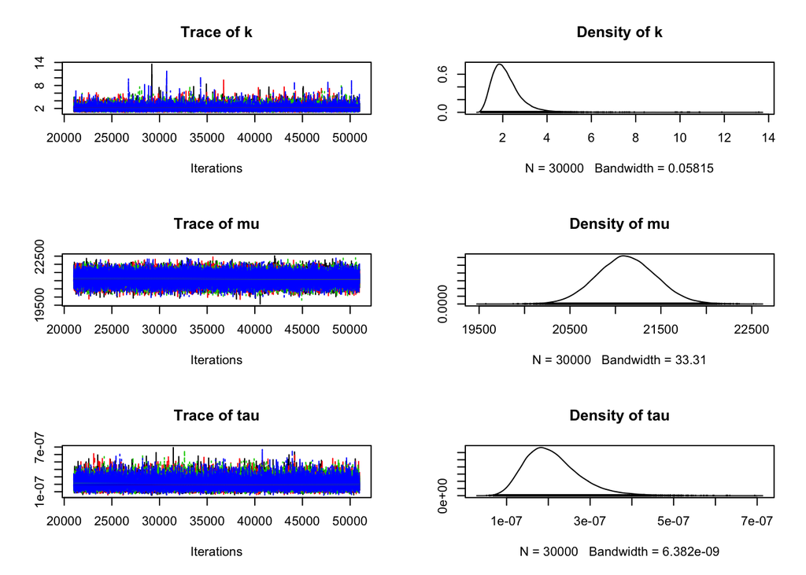

```r
jags.3.7.sum <- (summary(jags.samples.3.7))
plot(jags.samples.3.7)
```

The four chains did seem to converge well after the burn-in period and mixing was pretty good for all of them, with nice fuzzy trace plots. The trace for k is a little bit messy with some fairly large deviations from the bulk of the density, but it doesn’t seem to be worrying.

### c)

#### Graphically compare the t-distribution with parameters set to their posterior mean with the observed data. Does the model fit the data well?

```r
#First, transform the standard t-distribution function with some help from Wikipedia
dt_ls <- function(y, df, mu, sigma) {
  return(1/sigma * dt((y - mu)/sigma, df))
}
#Let's verify that it works
dt_ls(0, df=2, mu=0, sigma=1)
```

```
## [1] 0.3535534
```

```r
dt(0, df=2)
```

```
## [1] 0.3535534
```

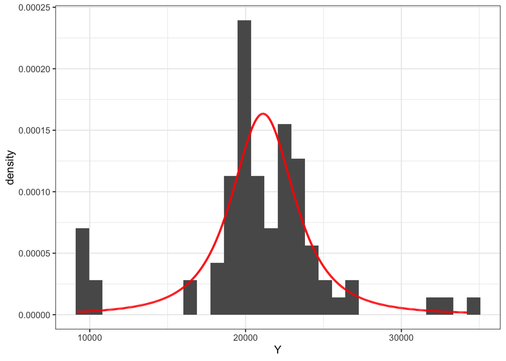

```r
#It does work

#Grab the posterior means from the JAGS output
jags.3.7.means <- as.numeric(c(jags.3.7.sum$statistics[1,1], jags.3.7.sum$statistics[2,1], jags.3.7.sum$statistics[3,1]))

#Plot a normalized histogram of the raw data and the t-distribution with parameters set as the posterior means
dat.3.7 <- data.frame(Y=Y)
ggplot(dat.3.7, aes(x=Y))+
  theme_bw()+
  geom_histogram(aes(x=Y, y=..density..))+
  stat_function(fun = dt_ls, args = list(df=jags.3.7.sum$statistics[1,1], mu=jags.3.7.sum$statistics[2,1], sigma=sqrt(1/jags.3.7.sum$statistics[3,1])), color="red", size=1, n=100000)
```

The model fits reasonably well, although the tails of the t-distribution don’t seem to be fat enough for this data. Still, it likely fits better than a normal distribution.